# Euler's Totient FINAL

Zachary Jock  
Mathematic and Scientific Computing  
February 15, 2024

```python
import math
import matplotlib.pyplot as plt
import numpy as np
import sympy
from math import log
```

## Introduction

Euler's Totient--written as $ɸ(n)$--is a value determined by the number of integers between 0 and n that are coprime to number n. In order for two positive numbers to be considered relatively prime or coprime, it is required that these integers have no other divisor in common aside from 1. Euler's Totient was discovered by the eponymous Leonhard Euler in 1763, originally denoted as πD before the standard notation was $ɸ(n)$ coined by Carl Friedrich Guass in 1801. The function provides an insight into the relationship between prime and non-prime numbers, and through centuries of research have lead us to modern marvels such as the RSA encryption system, which uses prime numbers to protect user data from malicious actors.[1][2][3]

In an ideal scenario this would be called the greatest common divisor or the GCD. Of course, the two integers must be prime hence the term coprime; We can demonstrate this property of prime numbers by using the `gcd` function from Python's math module.

```python
math.gcd(2,3)
```

```
1
```

```python
math.gcd(2,5)
```

```
1
```

```python
math.gcd(2,997)
```

```
1
```

`math.gcd` successfully demonstrates that regardless of magnitude, two prime numbers will share a GCD of 1, given that both integers can only divide by one and itself in ordinance with the rules of prime numbers. When we assign a non-prime number argument to the function, we will not obtain a GCD of 1.

```python
math.gcd(3,9)
```

```
3
```

```python
math.gcd(2,2480)
```

```
2
```

If we want to determine values for $ɸ(n)$, we can write a function that will only consider values that are coprime to our input argument. We can call this function `coprimelist`.

```python
def coprimelist(b): #Define a function that will list  n numbers less than input b with a GCD of 1
    coprime = [] #Create a list that stores n integers
    for n in range(b): # Range of n integers from 0 to input parameter b
        if math.gcd(n,b) == 1: #Condition where n integers and parameter b have a GCD of 1
            coprime.append(n) #When if condition is True, the n number will be added to the coprime list
    return coprime # Output the generated list in a sequence
```

Let's test `coprimelist` by using prime numbers 5,7,11, and 17 as inputs.

```python
coprimelist(5)
```

```
[1, 2, 3, 4]
```

```python
coprimelist(7)
```

```
[1, 2, 3, 4, 5, 6]
```

```python
coprimelist(11)
```

```
[1, 2, 3, 4, 5, 6, 7, 8, 9, 10]
```

```python
coprimelist(17)
```

```
[1, 2, 3, 4, 5, 6, 7, 8, 9, 10, 11, 12, 13, 14, 15, 16]
```

`math.gcd` will also provide an output for numbers that have a GCD of 1 with a non-prime value for `b`.

```python
coprimelist(6)
```

```
[1, 5]
```

```python
coprimelist(8)
```

```
[1, 3, 5, 7]
```

```python
coprimelist(16)
```

```
[1, 3, 5, 7, 9, 11, 13, 15]
```

As Euler's Totient is determined by the number of integers between 0 and n that are coprime to n, we must find the number from our `coprimelist` output by using `len()`. We can demonstrate the usage of `len(coprimelist(n))` with number 2,3,4 and 5.

```python
len(coprimelist(2))
```

```
1
```

```python
len(coprimelist(3))
```

```
2
```

```python
len(coprimelist(4))
```

```
2
```

```python
len(coprimelist(5))
```

```
4
```

**Note:** When using `len(coprimelist(n))` for n=1, the command will erroneously output `1`, despite `coprimelist(1)` providing the correct output of `[0]`. This is due to the `len()` command being designed to count the amount of entries in a list, which for values of n > 1 will provide the correct output for.

Using the `matplotlib` module, we can create a point graph using the data for the first 10 totient values provided below. The graph will be generated by a function we will define as `eulerto`, wherein a y function ($ɸ(n)$) is plotted with n numbers defined by user input and constrained by a horizontal range no greater than n.

n |1|2|3|4|5|6|7|8|9|10| **ɸ(n)**|0|1|2|2|4|2|6|4|6|4|

```python
def eulerto(n): # Define a function where Euler's Totient Function will be generated from 0 to integer n
    x = range(n) # Define the horizontal range for the function
    y = [len(coprimelist(n)) for n in x] # Output the amount of coprime numbers preceding number n
    y[1] = 0 #Replace the first number in the list with 0 so that phi(1) = 0
# Visable intervals for x and y
    plt.xlim(0,n)
    plt.ylim(0,n)
# Labels for our axes and header
    plt.xlabel('n')
    plt.ylabel('$ɸ(n)$')
    plt.title("Graph of Euler's Totient Outputs $ɸ(n)$")
# Generation and display of the graph
    plt.plot(x,y,'.')
    plt.show()
```

Now that we have a function that automatically plots an $ɸ(n)$ output for every $n$ integer, we can visualize a data set larger than our first ten $n$ values provided by the table.

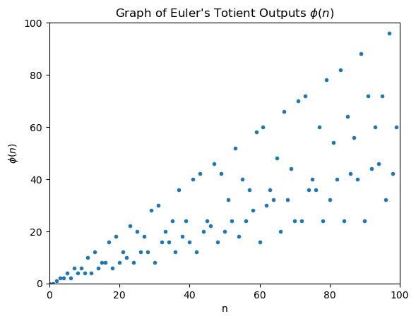

```python
eulerto(100)
```

Upon plotting our values of $ɸ(n)$ up to n = 100, we start to see interesting patterns develop, with points toward the top forming what looks to be a linear slope above what is otherwise scattered data. These patterns become more apparent when we raise our n value higher. Let's see what n = 1000 would look like.

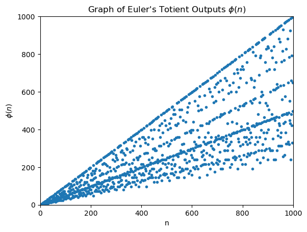

```python
eulerto(1000)
```

Although our graph output allows us to make observation of the linear equations that increase in prevalence with more data, plot points only tell us part of what is happening in Euler's Totient. We can modify our `eulerto` function to output Euler's Totient to display lines between plot points instead. We will call this function `eulerto_lines`.

```python
def eulerto_lines(n):
    x = range(n) # Define the horizontal range for the function
    y = [len(coprimelist(n)) for n in x] # Output the amount of coprime numbers preceding number n
    y[1] = 0 #Replace the first number in the list with 0 so that phi(1) = 0
# Visable intervals for x and y
    plt.xlim(0,n)
    plt.ylim(0,n)
# Labels for our axes and header
    plt.xlabel('n')
    plt.ylabel('$ɸ(n)$')
    plt.title("Graph of Euler's Totient Outputs $ɸ(n)$")
# Generation and display of the graph
    plt.plot(x,y,'--') # data will be plotted as dotted lines rather than isolated dots
    plt.show()
```

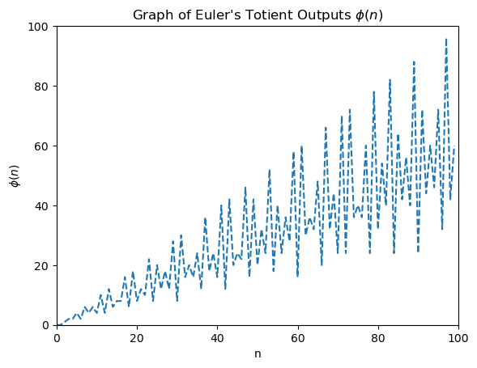

```python
eulerto_lines(100)
```

Not only can we observe linear trends within Euler's Totient function, but there seems to be an oscillation pattern happening as well. The goal of this paper is to analyze both the linear trends and oscillation trends of Euler's Totient and hypothesize on possible explanations for the function's particular characteristics. We can begin by analyzing the functions most apparent characteristic, that being its linear trend lines.

## Linear Equations on a Totient Graph $ɸ(n)$

We can start our analysis by observing the data for the first 10 values of $ɸ(n)$ and classifying values of n by their primality.

**Table (I): Totient Values for n ≤ 10** | | | | | | | | | | | | |---|---|---|---|---|---|---|---|---|---|---| n |1|2|3|4|5|6|7|8|9|10| **ɸ(n)**|0|1|2|2|4|2|6|4|6|4|

**Table (II): Prime Values of n**

n |2|3|5|7| **ɸ(n)**|1|2|4|6|

**Table (III): Non-prime Values of n**

n |1|4|6|8|9|10 **ɸ(n)**|0|2|2|4|6|4

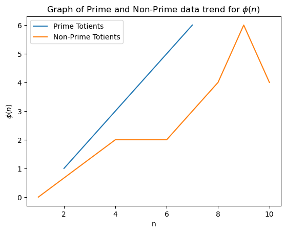

```python
# Table II
prime_n=[2,3,5,7]
prime_phi =[1,2,4,6]
# Table III
nonprime_n=[1,4,6,8,9,10]
nonprime_phi=[0,2,2,4,6,4]
# Labels for axes and header
plt.xlabel('n')
plt.ylabel('$ɸ(n)$')
#Generation and Display of graph
plt.plot(prime_n,prime_phi, label = 'Prime Totients')
plt.plot(nonprime_n,nonprime_phi, label = 'Non-Prime Totients')
plt.title("Graph of Prime and Non-Prime data trend for $ɸ(n)$ ")
plt.legend()
plt.show()
```

Since we can infer that prime number inputs will result in a linear trend for ɸ(n), we can further modify the graph to determine what linear slope equation that these prime values are bounded to. We can first observe Table II again for any indication of a trend.

**Table (II): Prime Values of n**

n |2|3|5|7| **ɸ(n)**|1|2|4|6|

Something to note in our table of n prime values is that ɸ(n) is always one less than its n input: ɸ(2) = 1, ɸ(3) = 2 and so on. Through this observation we can see that our linear equation would have a slope of $n$. Let's add our slope equation $ɸ(n)$ = $n$ to our graph above.

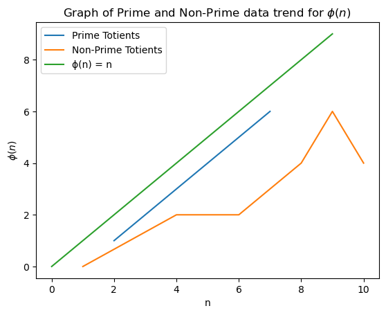

```python
# Table II
prime_n=[2,3,5,7]
prime_phi =[1,2,4,6]
# Table III
nonprime_n=[1,4,6,8,9,10]
nonprime_phi=[0,2,2,4,6,4]
#slope equation
slope= [(1*n) for n in range (0,10)]
# Labels for axes and header
plt.xlabel('n')
plt.ylabel('$ɸ(n)$')
#Generation and Display of graph
plt.plot(prime_n,prime_phi, label = 'Prime Totients')
plt.plot(nonprime_n,nonprime_phi, label = 'Non-Prime Totients')
plt.plot(slope, label = 'ɸ(n) = n')
plt.title("Graph of Prime and Non-Prime data trend for $ɸ(n)$ ")
plt.legend()
plt.show()
```

Not quite lined up, but our slope equation is parallel with our Prime Totients which indicates that they have the same slope but our y-intercept is not set to the correct value. However, Table (I) shows us that the n value that intersects with the y-axis, ɸ(n), is 1. We can modify the previous graph to adjust our y-intercept for the `slope` variable.

**Table (I): Totient Values for $n\le 10$**

**ɸ(n)**|0|1|2|2|4|2|6|4|6|4| n |1|2|3|4|5|6|7|8|9|10|

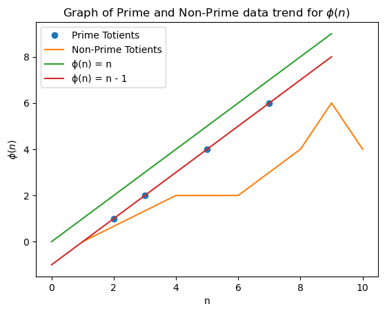

```python
# Table II
prime_n=[2,3,5,7]
prime_phi =[1,2,4,6]
# Table III
nonprime_n=[1,4,6,8,9,10]
nonprime_phi=[0,2,2,4,6,4]
#Slope equation from previous figure
slope= [(1*n) for n in range (0,10)]
#New slope equation with y-intercept b = -1 added
correct_slope= [(1*n-1) for n in range (0,10)]
# Labels for axes and header
plt.xlabel('n')
plt.ylabel('$ɸ(n)$')
#Generation and Display of graph
plt.plot(prime_n,prime_phi,'o', label = 'Prime Totients')
plt.plot(nonprime_n,nonprime_phi, label = 'Non-Prime Totients')
plt.plot(slope, label = 'ɸ(n) = n')
plt.plot(correct_slope, label = 'ɸ(n) = n - 1')
plt.title("Graph of Prime and Non-Prime data trend for $ɸ(n)$ ")
plt.legend()
plt.show()
```

From our graphical data, we can conclude that Euler's Totient function has a permanent upper boundary of n-1, where n is any prime number. But what about the other slope lines that we saw in the data earlier? Could they also have a relationship between the prime numbers in our data? We can test for other possible lines by plotting slope equations that have a slope value less than one. We will modify our `eulerto_with_slope` function to include `slope` functions with fractional slope values.

```python
x = range(10)
slope = [a - 1 for a in x]
slope1_2 = [1/2*a - 1  for a in x]
slope1_3 = [1/3*a - 1 for a in x]
slope1_4 = [1/4*a - 1 for a in x]
slope1_5 = [1/5*a - 1 for a in x]
plt.plot(x,slope, label = 'y = x-1')
plt.plot(x,slope1_2, label = 'y = 1/2x - 1')
plt.plot(x,slope1_3, label = 'y = 1/3x - 1')
plt.plot(x,slope1_4, label = 'y = 1/4x - 1')
plt.plot(x,slope1_5, label = 'y = 1/5x - 1')
plt.xlabel('x')
plt.ylabel('y')
plt.title("Graph of Linear Equations y = mx + b")
plt.legend()
plt.show()
```

[output not shown]

```python
def eulerto_with_slopes(n):
    x = range(n)
    y = [len(coprimelist(n)) for n in x]
    y[1] = 0
    slope = [(1*n - 1) for n in range(0,n)]
    slope1_2 = [1/2*a - 1 for a in x]
    slope1_3 = [1/3*a - 1 for a in x]
    slope1_4 = [1/4*a - 1 for a in x]
    slope1_5 = [1/5*a - 1 for a in x]

    plt.xlim(0,n)
    plt.ylim(0,n)
    plt.plot(x,y,'.')
    plt.plot(slope,'r-')
    plt.plot(x,slope, label = 'ɸ(n) = n - 1')
    plt.plot(x,slope1_2, label = 'ɸ(n) = 1/2n - 1')
    plt.plot(x,slope1_3, label = 'ɸ(n) = 1/3n - 1')
    plt.plot(x,slope1_4, label = 'ɸ(n) = 1/4n - 1')
    plt.plot(x,slope1_5, label = 'ɸ(n) = 1/5n - 1')
    plt.xlabel('n')
    plt.ylabel('$ɸ(n)$')
    plt.title("Graph of Euler's Totient $ɸ(n)$")
    plt.legend()
    plt.show()
```

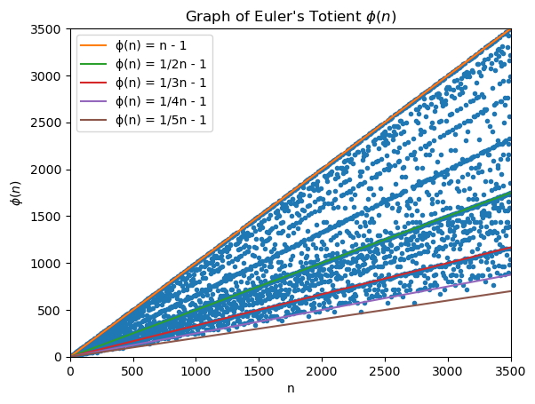

```python
eulerto_with_slopes(3500)
```

From our graph, we can observe a strong correlation of data points intersecting with $\frac{n}{2} - 1$ and $\frac{n}{3} - 1$ similar to $n - 1$, whereas $\frac{n}{4} - 1$ and $\frac{n}{5} - 1$ do not have as strong of a correlation. In order to speculate on why our data points correlate to selected linear equations, we can juxtapose our equations with the first ten Totient values of $ɸ(n)$. We can begin by comparing our Totient value table with the equation $\frac{n}{2} - 1$.

n |1|2|3|4|5|6|7|8|9|10| **ɸ(n)**|0|1|2|2|4|2|6|4|6|4|

In order to receive a proper Totient value, the output must be a natural number, therefore our $n$ input must divide into $2$ without any remainder; This will leave us only with even $n$ values.

n |2|4|6|8|10| **ɸ(n)**|1|2|2|4|4|

The standard method to determining Totient values is to take a prime value of take a prime value of $n$ and subtract by one as seen on previous graphical figures. But with our modified table of even $n$ values, we can solve algebraically for values of $ɸ(n)$ against our new linear boundary. $$ɸ(n) = \frac{n}{2} - 1$$ $$ɸ(2) = \frac{2}{2} - 1 = 0$$ $$ɸ(4) = \frac{4}{2} - 1 = 1$$ $$ɸ(6) = \frac{6}{2} - 1 = 2$$ $$ɸ(8) = \frac{8}{2} - 1 = 3$$ $$ɸ(10) = \frac{10}{2} - 1 =4$$

In our equation, $n$ will be divided by two to result in a quotient that is then subtracted by $1$, giving us our output for $ɸ(n)$. Something to note is that for every value of $n$ that results in a prime quotient (e.g. $\frac{4}{2} = {2}$), the equation will then mirror the procedure of the standard linear equation for determining Totient values, $ɸ(n) = n - 1$. $n$ values such as $4$ and $6$ will become $2$ and $3$ when divided in half, resulting in the same totient values as found in table. $n$ values $2$ and $8$ do not have the same results, which do not correlate with our $ɸ(n)$ values found in our tables since the quotient being subtracted is a non-prime number.

We can do this process automatically by modifying `coprimelist` to only consider integers with a GCD of 2 when paired with our n input. In the context of the previous example using $ɸ(n) = \frac{n}{2} - 1$, we will call this modified function `twoprimelist`

```python
def twoprimelist(b): #Define a function that will list  n numbers less than input b with a GCD of 1
    coprime = [] #Create a list that stores n integers
    for n in range(b): # Range of n integers from 0 to input parameter b
        if math.gcd(n,b) == 2: #Condition where n integers and parameter b have a GCD of 2
            coprime.append(n) #When if condition is True, the n number will be added to the coprime list
    return coprime # Output the generated list in a sequence
```

The function `twoprimelist` can be used with the `len()` command to determine Totient values just like `coprimelist`: Let's try numbers $4$, $8$, and $506$.

```python
twoprimelist(4)
```

```
[2]
```

```python
coprimelist(2)
```

```
[1]
```

```python
print(len(twoprimelist(4)))
```

```
1
```

```python
print(len(coprimelist(2)))
```

```
1
```

The function is determining how many numbers preceding the input have a GCD of 2 in common with said input. `len(twoprimelist(b)` will provide the amount of numbers in the list output of the function, which just so happens to share the same output as `len(coprimelist(2)` which suggests that our procedure of dividing $n$ by 2 is showing valid results.

```python
twoprimelist(8)
```

```
[2, 6]
```

```python
coprimelist(4)
```

```
[1, 3]
```

```python
print(len(twoprimelist(8)))
```

```
2
```

```python
len(twoprimelist(506))
```

```
220
```

```python
len(coprimelist(253))
```

```
220
```

`twoprimelist(506)` and `coprimelist(253)` show the same amount of output values in similar fashion to our other test variables, suggesting that our modified GCD algorithm is consistent for any even $n$ input value. We can generate a Totient function graph to show which values of $ɸ(n)$ are specifically bound to $ɸ(n) = \frac{n}{2} - 1$ given an $n$ range.

```python
def half_eulerto_scale(n):
    x = range(n)
    y = [len(twoprimelist(n)) for n in x]

    slope = [(1*n - 1) for n in range(0,n)]
    slope1_2 = [1/2*a - 1 for a in x]

    plt.xlim(0,n)
    plt.ylim(0,n)
    plt.plot(x,y,'.')
    plt.plot(x,slope,'r.', label = 'ɸ(n) = n - 1')
    plt.plot(x,slope1_2, label = 'ɸ(n) = 1/2n - 1')
    plt.xlabel('n')
    plt.ylabel('$ɸ(n)$')
    plt.title("Graph of Euler's Totient $ɸ(n)$ bound to $n/2 - 1$")
    plt.legend()
    plt.show()
```

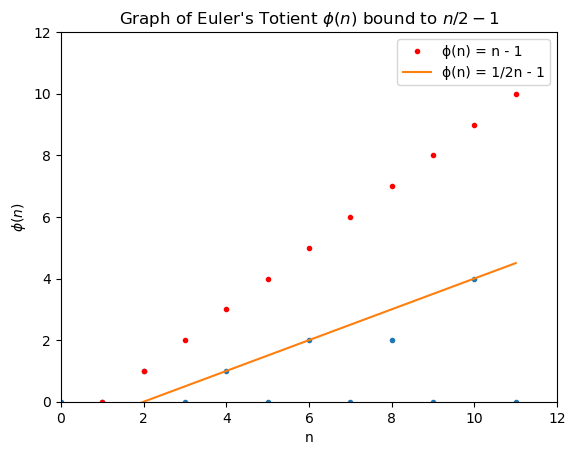

```python
half_eulerto_scale(12)
```

```python
def threeprimelist(b): #Define a function that will list  n numbers less than input b with a GCD of 1
    coprime = [] #Create a list that stores n integers
    for n in range(b): # Range of n integers from 0 to input parameter b
        if math.gcd(n,b) == 3: #Condition where n integers and parameter b have a GCD of 3
            coprime.append(n) #When if condition is True, the n number will be added to the coprime list
    return coprime # Output the generated list in a sequence
```

```python
def fiveprimelist(b): #Define a function that will list  n numbers less than input b with a GCD of 1
    coprime = [] #Create a list that stores n integers
    for n in range(b): # Range of n integers from 0 to input parameter b
        if math.gcd(n,b) == 5: #Condition where n integers and parameter b have a GCD of 5
            coprime.append(n) #When if condition is True, the n number will be added to the coprime list
    return coprime # Output the generated list in a sequence
```

We can graph `threeprimelist` and `fiveprimelist` in the same fashion as our other graphical figures to examine values of $n$ that are bound to $\frac{n}{3} - 1$ and $\frac{n}{5} - 1$.

```python
def third_eulerto_scale(n):
    x = range(n)
    y = [len(threeprimelist(n)) for n in x]
    z = [len(coprimelist(n)) for n in x]
    z[1] = 0
    slope = [(1*n - 1) for n in range(0,n)]
    slope1_3 = [1/3*a - 1 for a in x]

    plt.xlim(0,n)
    plt.ylim(0,n)
    plt.plot(x,y,'.')
    plt.plot(x,z,'k.' , label = "Normal Totient values")
    plt.plot(x,slope,'r.', label = 'ɸ(n) = n - 1')
    plt.plot(x,slope1_3, label = 'ɸ(n) = 1/2n - 1')
    plt.xlabel('n')
    plt.ylabel('$ɸ(n)$')
    plt.title("Graph of Euler's Totient $ɸ(n)$ bound to $n/3 - 1$")
    plt.legend()
    plt.show()
```

```python
def fifth_eulerto_scale(n):
    x = range(n)
    y = [len(fiveprimelist(n)) for n in x]
    z = [len(coprimelist(n)) for n in x]
    z[1] = 0
    slope = [(1*n - 1) for n in range(0,n)]
    slope1_5 = [1/5*a - 1 for a in x]

    plt.xlim(0,n)
    plt.ylim(0,n)
    plt.plot(x,y,'.')
    plt.plot(x,z,'k.' , label = "normal Totient values")
    plt.plot(x,slope,'r.', label = 'ɸ(n) = n - 1')
    plt.plot(x,slope1_5, label = 'ɸ(n) = 1/5n - 1')
    plt.xlabel('n')
    plt.ylabel('$ɸ(n)$')
    plt.title("Graph of Euler's Totient $ɸ(n)$ bound to $n/5 - 1$")
    plt.legend()
    plt.show()
```

[figure not shown]

```python
third_eulerto_scale(100)
```

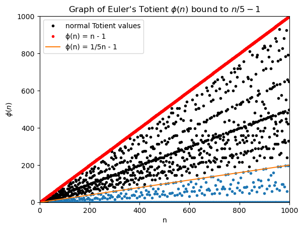

```python
fifth_eulerto_scale(1000)
```

## Oscillations for Composite integer data

Aside from our prime number n values, another important aspect of Euler's Totient function are the composite inputs, which behave differently on a graph in constrast to the linear behavior of prime numbers. Previously, we saw that generating Euler's Totient function with lines connecting the data instead of isolated points would show an oscillating pattern. We can create a modified version of `eulerto` that only takes composite/non-prime numbers as entries for $n$; We will call it `compgraph`.

```python
def compgraph(n):   #Alteration of our previous Euler's Totient function that only plots non-prime/composite data points
    h = [n for n in range(n+1) if not sympy.isprime(n)] #Generate a list of non-prime inputs for coprimelist function
    t = [len(coprimelist(n)) for n in h] # Find the amount of numbers coprime to h and compile them into a list.
    t[1] = 0 # Manually setting ɸ(1) = 0
    plt.xlim(0,n)
    plt.ylim(0,n)
    #Label our axes and header
    plt.xlabel('n')
    plt.ylabel('$ɸ(n)$')
    plt.title("Graph of Composite numbers for $ɸ(n)$")
    #Generate and display the Graph
    plt.plot(h,t,'-', label = "Composite Number Values")
    plt.legend()
    plt.show()
```

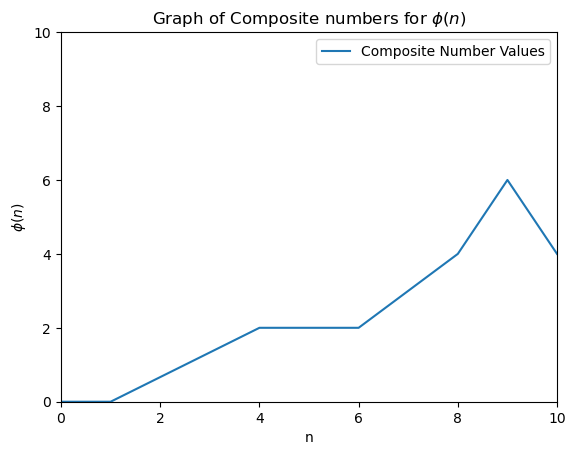

```python
compgraph(10)
```

To demonstrate its capability, let us generate the equivalent of `eulerto_lines(1000)` if only composite numbers were considered for plotting data.

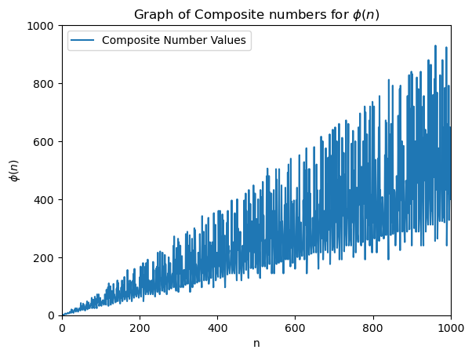

```python
compgraph(1000)
```

Upon observation, we can see that the composite-only function will oscillate in magnitude at what seems to be a consistent rate across the graph. A regression in Totient values can be observed through our table of ten values as seen previously.

**ɸ(n)**|0|1|2|2|4|2|6|4|6|4| n |1|2|3|4|5|6|7|8|9|10|

Let us compare the `len(coprimelist)` and `coprimelist` outputs for values $4$,$5$,$9$, and $10$.

```python
len(coprimelist(4))
```

```
2
```

```python
coprimelist(4)
```

```
[1, 3]
```

```python
len(coprimelist(5))
```

```
4
```

```python
coprimelist(5)
```

```
[1, 2, 3, 4]
```

```python
len(coprimelist(9))
```

```
6
```

```python
coprimelist(9)
```

```
[1, 2, 4, 5, 7, 8]
```

```python
len(coprimelist(10))
```

```
4
```

```python
coprimelist(10)
```

```
[1, 3, 7, 9]
```

```python
len(coprimelist(203020))
```

```
81200
```

```python
len(coprimelist(2023021))
```

```
1391040
```

Another observation to be made is that the function will increase in amplitude as $n$ approaches infinity; Of course, this is due to the magnitude of our output increasing in correlation with the magnitude of inputs. Something else to consider is the function's frequency: How would it behave as $n$ approaches infinity? Would it become shorter, longer, or stay the same? Given that prime numbers become more rare as $n$ approaches infinity, we can assume that the frequency of composite numbers would increase as the frequency of coprime numbers would decrease. We can try and test this hypothesis by generating various `compgraph` ranging in magnitude for $n$ and change the `plt.xlim` value to analyze specific intervals of the graph for changes in pattern.

For this experiment, we will use n values $100$,$1000$ and $7,500$ for `compgraph` to look for changes in the frequnecy of the oscillating pattern. The function will have a variable $p$ added to plot prime number totient values to ensure accuracy of results. Each iteration of `compgraph` will have its `plt.xlim` variable adjusted to observe an interval

```python
    n = 100 #Manually set our compgraph parameter to n=100
    h = [n for n in range(n+1) if not sympy.isprime(n)] #Generate a list of non-prime inputs for coprimelist function
    t = [len(coprimelist(n)) for n in h]
    t[1] = 0
    p = [n for n in range(n+1) if sympy.isprime(n)]
    r = [len(coprimelist(n)) for n in p]
    plt.xlim(0,100)
    plt.ylim(0,n)
    plt.plot(h,t,'-', label = 'Composite Number Values')
    plt.plot(p,r,'r.', label = 'Prime Number Values')
    plt.xlabel('n')
    plt.ylabel('$ɸ(n)$')
    plt.title("Graph of Composite numbers versus Prime numbers for $ɸ(n)$")
    plt.legend()
    plt.show()
```

[output not shown]

```python
    n = 1000
    h = [n for n in range(n+1) if not sympy.isprime(n)]
    t = [len(coprimelist(n)) for n in h]
    p = [n for n in range(n+1) if sympy.isprime(n)]
    r = [len(coprimelist(n)) for n in p]
    plt.xlim(900,1000)
    plt.ylim(0,n)
    plt.plot(h,t,'-', label = 'Composite Number Values')
    plt.plot(p,r,'r.', label = 'Prime Number Values')
    plt.xlabel('n')
    plt.ylabel('$ɸ(n)$')
    plt.title("Graph of Composite numbers versus Prime numbers for $ɸ(n)$")
    plt.legend()
    plt.show()
```

[output not shown]

```python
    n = 7500
    h = [n for n in range(n+1) if not sympy.isprime(n)]
    t = [len(coprimelist(n)) for n in h]
    p = [n for n in range(n+1) if sympy.isprime(n)]
    r = [len(coprimelist(n)) for n in p]
    plt.xlim(7400,7500)
    plt.ylim(0,7500)
    plt.plot(h,t,'-', label = 'Composite Number Values')
    plt.plot(p,r,'r.', label = 'Prime Number Values')
    plt.xlabel('n')
    plt.ylabel('$ɸ(n)$')
    plt.title("Graph of Composite numbers versus Prime numbers for $ɸ(n)$")
    plt.legend()
    plt.show()
```

[output not shown]

## Conclusion

Euler's Totient Function shows us the remarkable relationship between prime numbers and non-prime numbers despite the strict criteria that otherwise sets them apart. Within this report we were able to demonstrate that there are linear trends that can be derived from our data, which can be observed by plotting Euler's Totient against $ɸ(n) = n - 1$ as well as any prime fraction where the $n$ value is divided by a denominator to achieve a prime quotient to evaluate with $ɸ(n) = n - 1$. In addition to our linear equation trends, there is also a trend in our composite number data that tells us about the rarity of prime numbers as $n$ approaches infinity as well as the properties of prime factorization when observing the oscillation between odd and even integer values. Given that Leonhard Euler's work laid the groundwork for modern number theory and innovation involving prime numbers (e.g. RSA encryption), one can only assume that there are more phenomena to be studied beyond the scope of this report.

## References

1. Euler, L. (n.d.). In Wikipedia. Retrieved from https://en.wikipedia.org/wiki/Leonhard_Euler
2. Euler's totient function. (n.d.). In Wikipedia. Retrieved from https://en.wikipedia.org/wiki/Euler's_totient_function
3. RSA (cryptosystem). (n.d.). In Wikipedia. Retrieved from https://en.wikipedia.org/wiki/RSA_(cryptosystem)

```python
pwd
```

```
'/Users/zc04/Documents/Class files/MTH 337 - Mathematic and Scientific Computing'
```